# Loan Default Prediction

Jim Ryan

Originally completed March 2024; updated 2026

Part 1: Introduction

For this project I will use logistic regression to predict which applicants are likely to default on their loans. I am going to use the loans50k data set that was given to us as part of this assignment. This data set contains 50,000 loans in various statuses and various amounts. There are 32 available variables in the data set. My response variable will be the status variable. I will start by preparing and cleaning the data.

```r
LoansDT <- fread("Loans50k.csv")
```

Part 2: Preparing and Cleaning the Data

The data contains different variables collected as either part of the application process or information from when the loan was disbursed. I am trying to predict which variable or variables will allow me to predict whether a loan becomes default or not. I removed all loans that did not have a status of ‘Fully Paid’, ‘Default’ or ‘Charged Off’. Then I copied the response variable – status – into another field called status2. I then updated the status of loans that were Fully Paid to ‘Good’ and the ones that were ‘Default’ or ‘Charged Off’ to ‘Bad’.

There are 27,074 loans or 78% with a status of ‘Good’ and 7,581 loans or 22 percent with a status of ‘Bad’. Here is a Histogram of that shows the number of good and bad loans after the status has been updated.

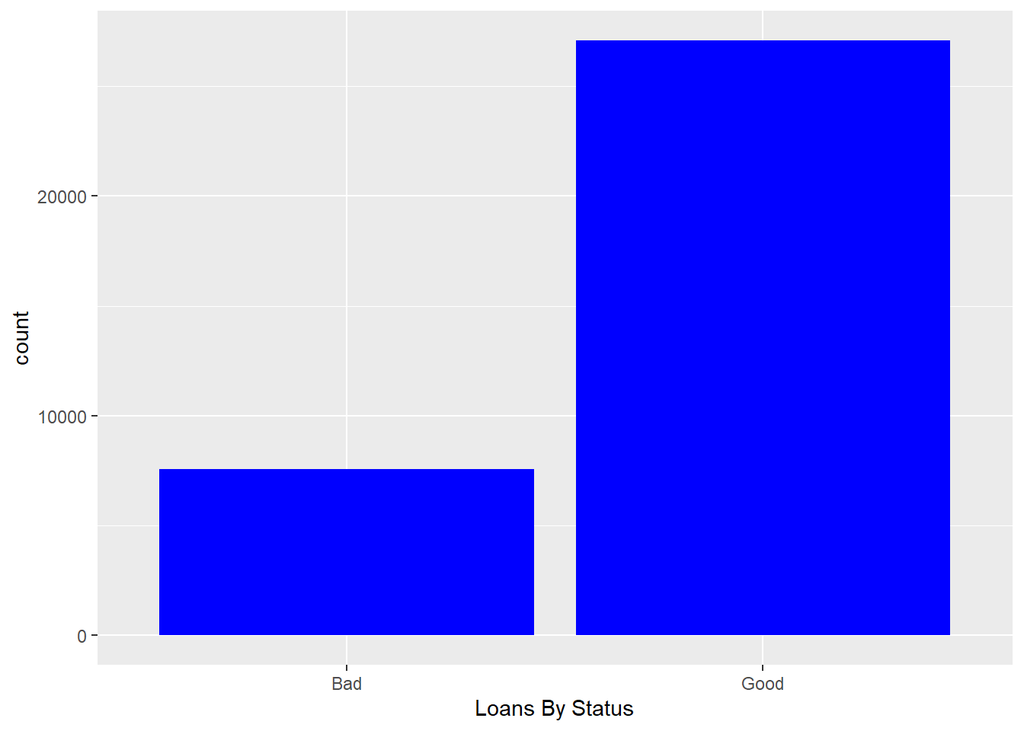

```r
#bar ploit on status
p1 <- ggplot(data=LoansDT, aes(x=status2)) +
      geom_bar(fill="blue") +
      xlab("Loans By Status")
p1
```

```r
#Update good to 1 bad to 0 and make var a factor
LoansDT <- sqldf(c("UPDATE LoansDT SET status2 = 1 where status2 = 'Good'","UPDATE LoansDT SET status2 = 0 where status2 = 'Bad'", "Select * from LoansDT"))
# set status field as factor
LoansDT$status2 <- as.factor(LoansDT$status2)
```

I used sapply with a sum on the NA in the data set to determine which variable had NA in them and how many there were. I found that the only 3 variables that had NA values in them were revolRatio (15 NA), bcOpen (360 NA) and bcRatio (384 NA).Since the missing values were only around 1 percent of the total number for these variables, I imputed them using the mean of all the values for that specific variable.

```
##      loanID      amount        term        rate     payment       grade
##           0           0           0           0           0           0
##  employment      length        home      income    verified      status
##           0           0           0           0           0           0
##      reason       state  debtIncRat   delinq2yr     inq6mth     openAcc
##           0           0           0           0           0           0
##      pubRec  revolRatio    totalAcc   totalPaid    totalBal totalRevLim
##           0          15           0           0           0           0
##   accOpen24      avgBal      bcOpen     bcRatio    totalLim totalRevBal
##           0           0         360         384           0           0
##  totalBcLim  totalIlLim     status2     amount2
##           0           0           0           0
```

The ‘Grade variable was updated from ‘A’ thru ‘G’ to 0 thru 6 and made into a factor. I update the ‘verified’ variable by updating those with a value of ‘Source Verified’ to ‘Verified’ and made that variable a factor. I did something similar with the home variable. I set the variable to OWN when the value was mortgage so then there were just 2 categorical variables - ‘own’ and ‘rent’ made the variable a factor. The variable term only had 2 values (36 months and 60 months) so the variable term2 was updated to a factor.

```r
sqldf("Select count(*) from LoansDT where employment like '%manager%' ")
```

```
##   count(*)
## 1     5228
```

```r
# update all employment rows with word manager in the to Manager
LoansDT <- sqldf(c("update  LoansDT set employment = 'manager' where employment like '%manager%'","Select * from LoansDT"))

# update all employment rows with word manager in the to manager
LoansDT <- sqldf(c("update  LoansDT set employment = 'Teacher' where employment like '%teach%'","Select * from LoansDT"))


#Update grade to numeric (0 thru 6)
 LoansDT <- sqldf(c("UPDATE LoansDT SET grade = CASE grade WHEN 'A' THEN 0 WHEN 'B' THEN 1  WHEN 'C' THEN 2  WHEN 'D' THEN 3 WHEN 'E' THEN 4 WHEN 'F' THEN 5 WHEN 'G' THEN 6 END","Select * from LoansDT"))
# set grade as a factor
 LoansDT$grade <- as.factor(LoansDT$grade)

#Update home to OWN when value is mortgage, set own = 1 and rent = 0 and maake it a factor
 LoansDT <- sqldf(c("Update LoansDT set home = 'OWN' where home = 'MORTGAGE'","Select * from LoansDT"))
  LoansDT$home <- as.factor(LoansDT$home)

# Update  Source Verified amd Verified to 1 Not verified as 0 make it a factor
  LoansDT <- sqldf(c("UPDATE LoansDT SET verified =  'Verified' where verified =  'Source Verified'","Select * from LoansDT"))

 LoansDT$verified <- as.factor(LoansDT$verified)

# make term column a factor
LoansDT$term <- as.factor(LoansDT$term)
```

I removed the following variables because more than 25 percent of them were 0: pubRec, delinq2yr, and inq6mth. I also dropped the original status variable.

```r
# remove original status and original term columns
LoansDT$status <- NULL

colnames(LoansDT)
```

```
##  [1] "loanID"      "amount"      "term"        "rate"        "payment"
##  [6] "grade"       "employment"  "length"      "home"        "income"
## [11] "verified"    "reason"      "state"       "debtIncRat"  "delinq2yr"
## [16] "inq6mth"     "openAcc"     "pubRec"      "revolRatio"  "totalAcc"
## [21] "totalPaid"   "totalBal"    "totalRevLim" "accOpen24"   "avgBal"
## [26] "bcOpen"      "bcRatio"     "totalLim"    "totalRevBal" "totalBcLim"
## [31] "totalIlLim"  "status2"     "amount2"
```

```r
sqldf ("select count (*) from LoansDT where pubRec = 0 ")
```

```
##   count (*)
## 1     28076
```

```r
sqldf ("select count (*) from LoansDT where delinq2yr = 0 ")
```

```
##   count (*)
## 1     27600
```

```r
sqldf ("select count (*) from LoansDT where inq6mth = 0 ")
```

```
##   count (*)
## 1     19237
```

```r
sqldf ("select count(distinct(employment)) from LoansDT")
```

```
##   count(distinct(employment))
## 1                       13368
```

```r
# following columns are removed as over 25% of values are blank or 0
LoansDT$pubRec <- NULL
LoansDT$delinq2yr <- NULL
LoansDT$inq6mth <- NULL
```

Part 4:Exploring and Transforming the Data

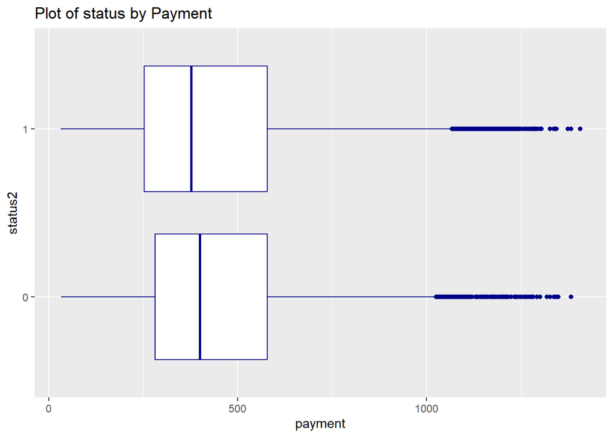

```r
par(mfrow=c(2,2))
ggplot(aes(x=payment,y=status2),data=LoansDT)+
  geom_boxplot(color='darkblue') + ggtitle("Plot of status by Payment")
```

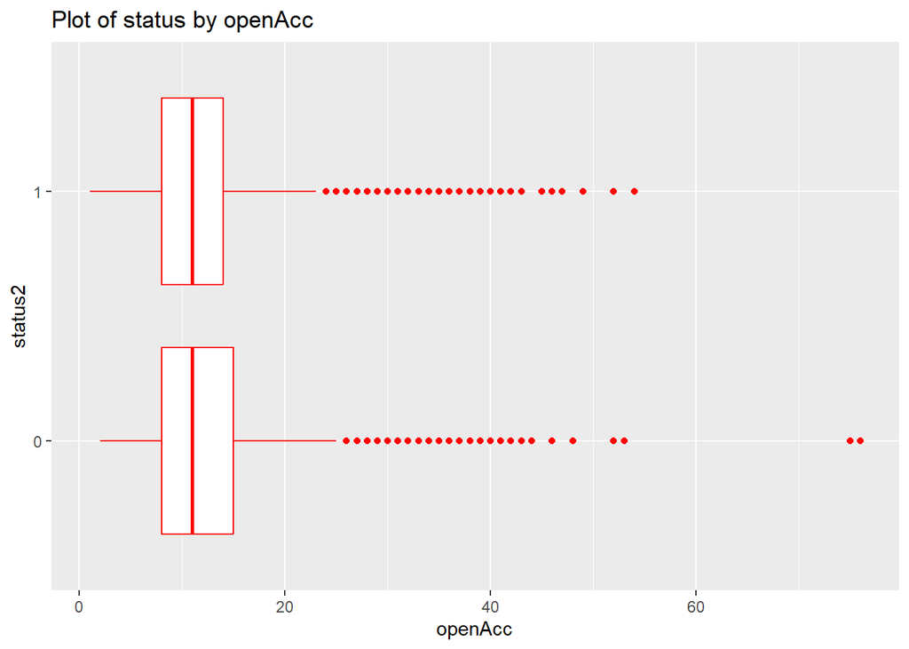

```r
ggplot(aes(x=openAcc,y=status2),data=LoansDT)+
  geom_boxplot(color='red') + ggtitle("Plot of status by openAcc")
```

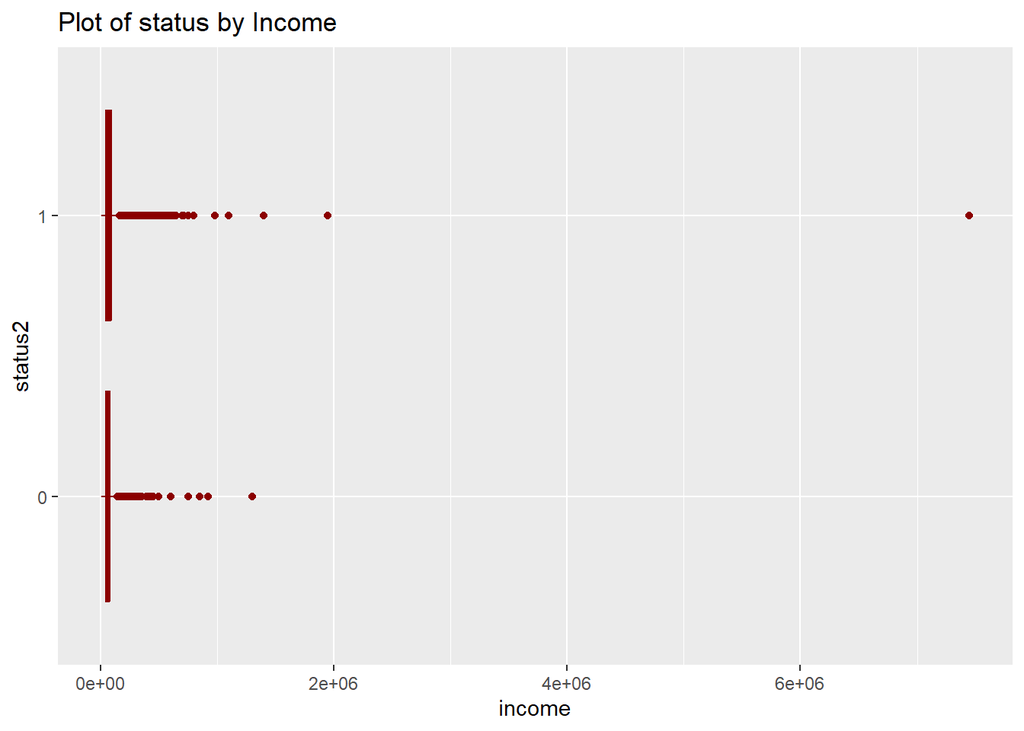

```r
ggplot(aes(x=income,y=status2),data=LoansDT)+
  geom_boxplot(color='darkred')  + ggtitle("Plot of status by Income")
```

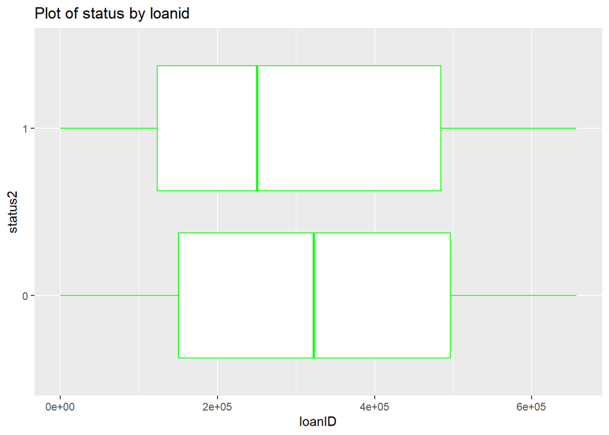

```r
ggplot(aes(x=loanID,y=status2),data=LoansDT)+
  geom_boxplot(color='green')  + ggtitle("Plot of status by loanid")
```

```r
LoansDT$loanID <- NULL
```

Then I divided up my modified data frame into good and bad loans based on the status2 variable. Then I made bar graphs of some of the categorical variables divided by good and bad loans to see if there were any obvious relationships. I plotted the ‘term’, ‘verified’ and home variable against status2 For the term variable ‘bad’ loans have a greater percentage of loans with 60 month terms than the ‘good’ loans. It appears that there might be some relationship between the ‘verified’ and term variables and status. I will keep this variables for part 5.

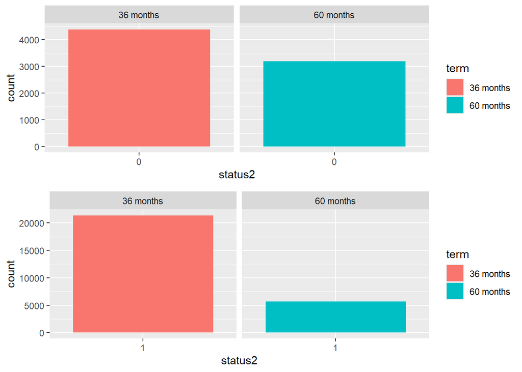

```r
library("gridExtra")
loans_bad <- sqldf("Select * from LoansDT where status2 = 0")
loans_good <- sqldf("Select * from LoansDT where status2 = 1")


p1 <- ggplot(loans_bad, aes(status2, fill = term)) + facet_wrap(~term)  + geom_bar()
p2 <- ggplot(loans_good, aes(status2, fill = term)) + facet_wrap(~term) + geom_bar()


p3 <- ggplot(loans_bad, aes(status2, fill = verified)) + facet_wrap(~verified) + geom_bar()
p4 <- ggplot(loans_good, aes(status2, fill = verified)) + facet_wrap(~verified) + geom_bar()


p5 <- ggplot(loans_bad, aes(status2, fill = home)) + facet_wrap(~home) + geom_bar()
p6 <- ggplot(loans_good, aes(status2, fill = home)) + facet_wrap(~home) + geom_bar()

grid.arrange(p1,p2)
```

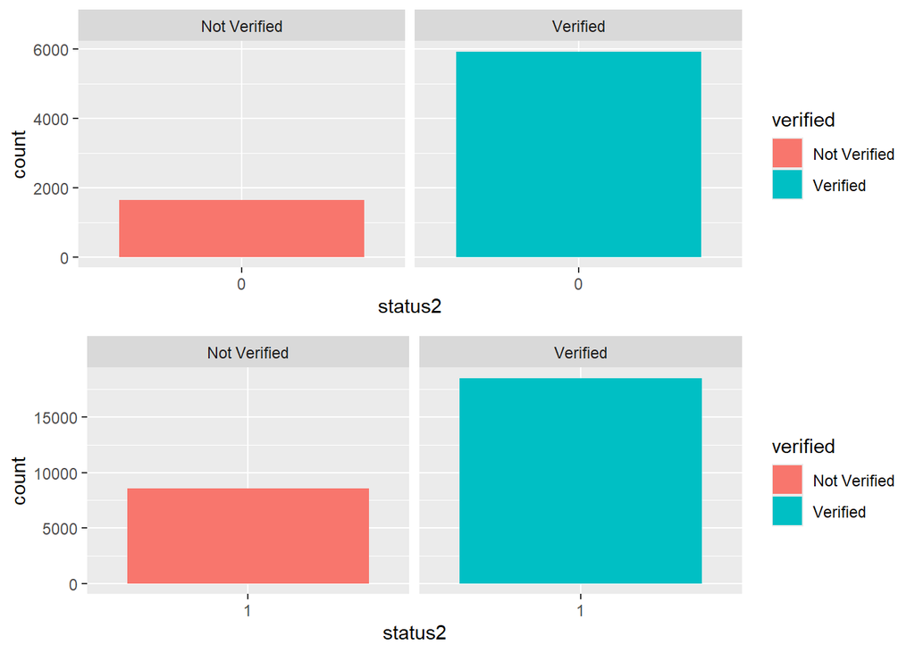

```r
grid.arrange(p3,p4)
```